# Optimal Treatment Analysis

## Outcome Variable

**Outcome Variable:** ever_stunted

## Predictor Variables

**Intervention Variable:** lag_WHZ_quart

**Adjustment Set:**

- arm
- sex
- W_mage
- meducyrs
- feducyrs
- single
- month
- brthmon
- delta_W_mage
- delta_meducyrs
- delta_feducyrs
- delta_single
- delta_month
- delta_brthmon

## Stratifying Variables

The analysis was stratified on these variable(s):

- agecat
- studyid
- country

## Data Summary

| agecat | studyid | country | lag_WHZ_quart | ever_stunted | n_cell | n |
| --- | --- | --- | --- | --- | --- | --- |
| 3-6 months | ki0047075b-MAL-ED | BANGLADESH | 1 | 0 | 43 | 207 |
| 3-6 months | ki0047075b-MAL-ED | BANGLADESH | 1 | 1 | 5 | 207 |
| 3-6 months | ki0047075b-MAL-ED | BANGLADESH | 2 | 0 | 78 | 207 |
| 3-6 months | ki0047075b-MAL-ED | BANGLADESH | 2 | 1 | 14 | 207 |
| 3-6 months | ki0047075b-MAL-ED | BANGLADESH | 3 | 0 | 51 | 207 |
| 3-6 months | ki0047075b-MAL-ED | BANGLADESH | 3 | 1 | 8 | 207 |
| 3-6 months | ki0047075b-MAL-ED | BANGLADESH | 4 | 0 | 7 | 207 |
| 3-6 months | ki0047075b-MAL-ED | BANGLADESH | 4 | 1 | 1 | 207 |
| 3-6 months | ki0047075b-MAL-ED | BRAZIL | 1 | 0 | 32 | 201 |
| 3-6 months | ki0047075b-MAL-ED | BRAZIL | 1 | 1 | 1 | 201 |
| 3-6 months | ki0047075b-MAL-ED | BRAZIL | 2 | 0 | 90 | 201 |
| 3-6 months | ki0047075b-MAL-ED | BRAZIL | 2 | 1 | 5 | 201 |
| 3-6 months | ki0047075b-MAL-ED | BRAZIL | 3 | 0 | 50 | 201 |
| 3-6 months | ki0047075b-MAL-ED | BRAZIL | 3 | 1 | 3 | 201 |
| 3-6 months | ki0047075b-MAL-ED | BRAZIL | 4 | 0 | 16 | 201 |
| 3-6 months | ki0047075b-MAL-ED | BRAZIL | 4 | 1 | 4 | 201 |
| 3-6 months | ki0047075b-MAL-ED | INDIA | 1 | 0 | 65 | 199 |
| 3-6 months | ki0047075b-MAL-ED | INDIA | 1 | 1 | 13 | 199 |
| 3-6 months | ki0047075b-MAL-ED | INDIA | 2 | 0 | 65 | 199 |
| 3-6 months | ki0047075b-MAL-ED | INDIA | 2 | 1 | 9 | 199 |
| 3-6 months | ki0047075b-MAL-ED | INDIA | 3 | 0 | 30 | 199 |
| 3-6 months | ki0047075b-MAL-ED | INDIA | 3 | 1 | 8 | 199 |
| 3-6 months | ki0047075b-MAL-ED | INDIA | 4 | 0 | 4 | 199 |
| 3-6 months | ki0047075b-MAL-ED | INDIA | 4 | 1 | 5 | 199 |
| 3-6 months | ki0047075b-MAL-ED | NEPAL | 1 | 0 | 43 | 210 |
| 3-6 months | ki0047075b-MAL-ED | NEPAL | 1 | 1 | 0 | 210 |
| 3-6 months | ki0047075b-MAL-ED | NEPAL | 2 | 0 | 80 | 210 |
| 3-6 months | ki0047075b-MAL-ED | NEPAL | 2 | 1 | 2 | 210 |
| 3-6 months | ki0047075b-MAL-ED | NEPAL | 3 | 0 | 68 | 210 |
| 3-6 months | ki0047075b-MAL-ED | NEPAL | 3 | 1 | 3 | 210 |

[output cut: 882 more lines]

The following strata were considered:

- agecat: 12-15 months, studyid: ki0047075b-MAL-ED, country: BANGLADESH
- agecat: 12-15 months, studyid: ki0047075b-MAL-ED, country: BRAZIL
- agecat: 12-15 months, studyid: ki0047075b-MAL-ED, country: INDIA
- agecat: 12-15 months, studyid: ki0047075b-MAL-ED, country: NEPAL
- agecat: 12-15 months, studyid: ki0047075b-MAL-ED, country: PERU
- agecat: 12-15 months, studyid: ki0047075b-MAL-ED, country: SOUTH AFRICA
- agecat: 12-15 months, studyid: ki0047075b-MAL-ED, country: TANZANIA, UNITED REPUBLIC OF
- agecat: 12-15 months, studyid: ki1000108-CMC-V-BCS-2002, country: INDIA
- agecat: 12-15 months, studyid: ki1000108-IRC, country: INDIA
- agecat: 12-15 months, studyid: ki1000109-EE, country: PAKISTAN
- agecat: 12-15 months, studyid: ki1017093b-PROVIDE, country: BANGLADESH
- agecat: 12-15 months, studyid: ki1066203-TanzaniaChild2, country: TANZANIA, UNITED REPUBLIC OF
- agecat: 12-15 months, studyid: ki1101329-Keneba, country: GAMBIA
- agecat: 12-15 months, studyid: ki1112895-Guatemala BSC, country: GUATEMALA
- agecat: 12-15 months, studyid: ki1113344-GMS-Nepal, country: NEPAL
- agecat: 12-15 months, studyid: ki1114097-CMIN, country: BANGLADESH
- agecat: 12-15 months, studyid: ki1114097-CMIN, country: PERU
- agecat: 15-18 months, studyid: ki0047075b-MAL-ED, country: BANGLADESH
- agecat: 15-18 months, studyid: ki0047075b-MAL-ED, country: BRAZIL
- agecat: 15-18 months, studyid: ki0047075b-MAL-ED, country: INDIA
- agecat: 15-18 months, studyid: ki0047075b-MAL-ED, country: NEPAL
- agecat: 15-18 months, studyid: ki0047075b-MAL-ED, country: PERU
- agecat: 15-18 months, studyid: ki0047075b-MAL-ED, country: SOUTH AFRICA
- agecat: 15-18 months, studyid: ki0047075b-MAL-ED, country: TANZANIA, UNITED REPUBLIC OF
- agecat: 15-18 months, studyid: ki1000108-CMC-V-BCS-2002, country: INDIA
- agecat: 15-18 months, studyid: ki1000108-IRC, country: INDIA
- agecat: 15-18 months, studyid: ki1000109-EE, country: PAKISTAN
- agecat: 15-18 months, studyid: ki1017093b-PROVIDE, country: BANGLADESH
- agecat: 15-18 months, studyid: ki1066203-TanzaniaChild2, country: TANZANIA, UNITED REPUBLIC OF
- agecat: 15-18 months, studyid: ki1101329-Keneba, country: GAMBIA
- agecat: 15-18 months, studyid: ki1112895-Guatemala BSC, country: GUATEMALA
- agecat: 15-18 months, studyid: ki1113344-GMS-Nepal, country: NEPAL
- agecat: 15-18 months, studyid: ki1114097-CMIN, country: BANGLADESH
- agecat: 15-18 months, studyid: ki1114097-CMIN, country: PERU
- agecat: 18-21 months, studyid: ki0047075b-MAL-ED, country: BANGLADESH
- agecat: 18-21 months, studyid: ki0047075b-MAL-ED, country: BRAZIL
- agecat: 18-21 months, studyid: ki0047075b-MAL-ED, country: INDIA
- agecat: 18-21 months, studyid: ki0047075b-MAL-ED, country: NEPAL
- agecat: 18-21 months, studyid: ki0047075b-MAL-ED, country: PERU
- agecat: 18-21 months, studyid: ki0047075b-MAL-ED, country: SOUTH AFRICA
- agecat: 18-21 months, studyid: ki0047075b-MAL-ED, country: TANZANIA, UNITED REPUBLIC OF
- agecat: 18-21 months, studyid: ki1000108-CMC-V-BCS-2002, country: INDIA
- agecat: 18-21 months, studyid: ki1000108-IRC, country: INDIA
- agecat: 18-21 months, studyid: ki1000109-EE, country: PAKISTAN
- agecat: 18-21 months, studyid: ki1017093b-PROVIDE, country: BANGLADESH
- agecat: 18-21 months, studyid: ki1066203-TanzaniaChild2, country: TANZANIA, UNITED REPUBLIC OF
- agecat: 18-21 months, studyid: ki1101329-Keneba, country: GAMBIA
- agecat: 18-21 months, studyid: ki1113344-GMS-Nepal, country: NEPAL
- agecat: 18-21 months, studyid: ki1114097-CMIN, country: BANGLADESH
- agecat: 18-21 months, studyid: ki1114097-CMIN, country: PERU
- agecat: 21-24 months, studyid: ki0047075b-MAL-ED, country: BANGLADESH
- agecat: 21-24 months, studyid: ki0047075b-MAL-ED, country: BRAZIL
- agecat: 21-24 months, studyid: ki0047075b-MAL-ED, country: INDIA
- agecat: 21-24 months, studyid: ki0047075b-MAL-ED, country: NEPAL
- agecat: 21-24 months, studyid: ki0047075b-MAL-ED, country: PERU
- agecat: 21-24 months, studyid: ki0047075b-MAL-ED, country: SOUTH AFRICA
- agecat: 21-24 months, studyid: ki0047075b-MAL-ED, country: TANZANIA, UNITED REPUBLIC OF
- agecat: 21-24 months, studyid: ki1000108-CMC-V-BCS-2002, country: INDIA
- agecat: 21-24 months, studyid: ki1000108-IRC, country: INDIA
- agecat: 21-24 months, studyid: ki1017093b-PROVIDE, country: BANGLADESH
- agecat: 21-24 months, studyid: ki1066203-TanzaniaChild2, country: TANZANIA, UNITED REPUBLIC OF
- agecat: 21-24 months, studyid: ki1101329-Keneba, country: GAMBIA
- agecat: 21-24 months, studyid: ki1113344-GMS-Nepal, country: NEPAL
- agecat: 21-24 months, studyid: ki1114097-CMIN, country: BANGLADESH
- agecat: 21-24 months, studyid: ki1114097-CMIN, country: PERU
- agecat: 3-6 months, studyid: ki0047075b-MAL-ED, country: BANGLADESH
- agecat: 3-6 months, studyid: ki0047075b-MAL-ED, country: BRAZIL
- agecat: 3-6 months, studyid: ki0047075b-MAL-ED, country: INDIA
- agecat: 3-6 months, studyid: ki0047075b-MAL-ED, country: NEPAL
- agecat: 3-6 months, studyid: ki0047075b-MAL-ED, country: PERU
- agecat: 3-6 months, studyid: ki0047075b-MAL-ED, country: SOUTH AFRICA
- agecat: 3-6 months, studyid: ki0047075b-MAL-ED, country: TANZANIA, UNITED REPUBLIC OF
- agecat: 3-6 months, studyid: ki1000108-CMC-V-BCS-2002, country: INDIA
- agecat: 3-6 months, studyid: ki1000108-IRC, country: INDIA
- agecat: 3-6 months, studyid: ki1000109-EE, country: PAKISTAN
- agecat: 3-6 months, studyid: ki1017093b-PROVIDE, country: BANGLADESH
- agecat: 3-6 months, studyid: ki1066203-TanzaniaChild2, country: TANZANIA, UNITED REPUBLIC OF
- agecat: 3-6 months, studyid: ki1101329-Keneba, country: GAMBIA
- agecat: 3-6 months, studyid: ki1112895-Guatemala BSC, country: GUATEMALA
- agecat: 3-6 months, studyid: ki1114097-CMIN, country: BANGLADESH
- agecat: 3-6 months, studyid: ki1114097-CMIN, country: PERU
- agecat: 6-9 months, studyid: ki0047075b-MAL-ED, country: BANGLADESH
- agecat: 6-9 months, studyid: ki0047075b-MAL-ED, country: BRAZIL
- agecat: 6-9 months, studyid: ki0047075b-MAL-ED, country: INDIA
- agecat: 6-9 months, studyid: ki0047075b-MAL-ED, country: NEPAL
- agecat: 6-9 months, studyid: ki0047075b-MAL-ED, country: PERU
- agecat: 6-9 months, studyid: ki0047075b-MAL-ED, country: SOUTH AFRICA
- agecat: 6-9 months, studyid: ki0047075b-MAL-ED, country: TANZANIA, UNITED REPUBLIC OF
- agecat: 6-9 months, studyid: ki1000108-CMC-V-BCS-2002, country: INDIA
- agecat: 6-9 months, studyid: ki1000108-IRC, country: INDIA
- agecat: 6-9 months, studyid: ki1000109-EE, country: PAKISTAN
- agecat: 6-9 months, studyid: ki1017093b-PROVIDE, country: BANGLADESH
- agecat: 6-9 months, studyid: ki1066203-TanzaniaChild2, country: TANZANIA, UNITED REPUBLIC OF
- agecat: 6-9 months, studyid: ki1101329-Keneba, country: GAMBIA
- agecat: 6-9 months, studyid: ki1112895-Guatemala BSC, country: GUATEMALA
- agecat: 6-9 months, studyid: ki1114097-CMIN, country: BANGLADESH
- agecat: 6-9 months, studyid: ki1114097-CMIN, country: PERU
- agecat: 9-12 months, studyid: ki0047075b-MAL-ED, country: BANGLADESH
- agecat: 9-12 months, studyid: ki0047075b-MAL-ED, country: BRAZIL
- agecat: 9-12 months, studyid: ki0047075b-MAL-ED, country: INDIA
- agecat: 9-12 months, studyid: ki0047075b-MAL-ED, country: NEPAL
- agecat: 9-12 months, studyid: ki0047075b-MAL-ED, country: PERU
- agecat: 9-12 months, studyid: ki0047075b-MAL-ED, country: SOUTH AFRICA
- agecat: 9-12 months, studyid: ki0047075b-MAL-ED, country: TANZANIA, UNITED REPUBLIC OF
- agecat: 9-12 months, studyid: ki1000108-CMC-V-BCS-2002, country: INDIA
- agecat: 9-12 months, studyid: ki1000108-IRC, country: INDIA
- agecat: 9-12 months, studyid: ki1000109-EE, country: PAKISTAN
- agecat: 9-12 months, studyid: ki1017093b-PROVIDE, country: BANGLADESH
- agecat: 9-12 months, studyid: ki1066203-TanzaniaChild2, country: TANZANIA, UNITED REPUBLIC OF
- agecat: 9-12 months, studyid: ki1101329-Keneba, country: GAMBIA
- agecat: 9-12 months, studyid: ki1112895-Guatemala BSC, country: GUATEMALA
- agecat: 9-12 months, studyid: ki1113344-GMS-Nepal, country: NEPAL
- agecat: 9-12 months, studyid: ki1114097-CMIN, country: BANGLADESH
- agecat: 9-12 months, studyid: ki1114097-CMIN, country: PERU

### Dropped Strata

Some strata were dropped due to rare outcomes:

- agecat: 3-6 months, studyid: ki0047075b-MAL-ED, country: BANGLADESH
- agecat: 3-6 months, studyid: ki0047075b-MAL-ED, country: BRAZIL
- agecat: 3-6 months, studyid: ki0047075b-MAL-ED, country: INDIA
- agecat: 3-6 months, studyid: ki0047075b-MAL-ED, country: NEPAL
- agecat: 3-6 months, studyid: ki0047075b-MAL-ED, country: PERU
- agecat: 3-6 months, studyid: ki0047075b-MAL-ED, country: SOUTH AFRICA
- agecat: 3-6 months, studyid: ki0047075b-MAL-ED, country: TANZANIA, UNITED REPUBLIC OF
- agecat: 3-6 months, studyid: ki1000108-CMC-V-BCS-2002, country: INDIA
- agecat: 3-6 months, studyid: ki1000108-IRC, country: INDIA
- agecat: 3-6 months, studyid: ki1000109-EE, country: PAKISTAN
- agecat: 3-6 months, studyid: ki1112895-Guatemala BSC, country: GUATEMALA
- agecat: 3-6 months, studyid: ki1114097-CMIN, country: BANGLADESH
- agecat: 6-9 months, studyid: ki0047075b-MAL-ED, country: BANGLADESH
- agecat: 6-9 months, studyid: ki0047075b-MAL-ED, country: BRAZIL
- agecat: 6-9 months, studyid: ki0047075b-MAL-ED, country: INDIA
- agecat: 6-9 months, studyid: ki0047075b-MAL-ED, country: NEPAL
- agecat: 6-9 months, studyid: ki1000108-CMC-V-BCS-2002, country: INDIA
- agecat: 6-9 months, studyid: ki1000108-IRC, country: INDIA
- agecat: 6-9 months, studyid: ki1000109-EE, country: PAKISTAN
- agecat: 6-9 months, studyid: ki1017093b-PROVIDE, country: BANGLADESH
- agecat: 6-9 months, studyid: ki1114097-CMIN, country: BANGLADESH
- agecat: 9-12 months, studyid: ki0047075b-MAL-ED, country: BANGLADESH
- agecat: 9-12 months, studyid: ki0047075b-MAL-ED, country: BRAZIL
- agecat: 9-12 months, studyid: ki0047075b-MAL-ED, country: INDIA
- agecat: 9-12 months, studyid: ki0047075b-MAL-ED, country: NEPAL
- agecat: 9-12 months, studyid: ki0047075b-MAL-ED, country: PERU
- agecat: 9-12 months, studyid: ki0047075b-MAL-ED, country: SOUTH AFRICA
- agecat: 9-12 months, studyid: ki1000108-CMC-V-BCS-2002, country: INDIA
- agecat: 9-12 months, studyid: ki1000108-IRC, country: INDIA
- agecat: 9-12 months, studyid: ki1000109-EE, country: PAKISTAN
- agecat: 9-12 months, studyid: ki1017093b-PROVIDE, country: BANGLADESH
- agecat: 9-12 months, studyid: ki1101329-Keneba, country: GAMBIA
- agecat: 9-12 months, studyid: ki1112895-Guatemala BSC, country: GUATEMALA
- agecat: 9-12 months, studyid: ki1113344-GMS-Nepal, country: NEPAL
- agecat: 9-12 months, studyid: ki1114097-CMIN, country: BANGLADESH
- agecat: 12-15 months, studyid: ki0047075b-MAL-ED, country: BANGLADESH
- agecat: 12-15 months, studyid: ki0047075b-MAL-ED, country: BRAZIL
- agecat: 12-15 months, studyid: ki0047075b-MAL-ED, country: INDIA
- agecat: 12-15 months, studyid: ki0047075b-MAL-ED, country: NEPAL
- agecat: 12-15 months, studyid: ki0047075b-MAL-ED, country: PERU
- agecat: 12-15 months, studyid: ki0047075b-MAL-ED, country: SOUTH AFRICA
- agecat: 12-15 months, studyid: ki1000108-CMC-V-BCS-2002, country: INDIA
- agecat: 12-15 months, studyid: ki1000108-IRC, country: INDIA
- agecat: 12-15 months, studyid: ki1000109-EE, country: PAKISTAN
- agecat: 12-15 months, studyid: ki1017093b-PROVIDE, country: BANGLADESH
- agecat: 12-15 months, studyid: ki1112895-Guatemala BSC, country: GUATEMALA
- agecat: 12-15 months, studyid: ki1113344-GMS-Nepal, country: NEPAL
- agecat: 12-15 months, studyid: ki1114097-CMIN, country: BANGLADESH
- agecat: 15-18 months, studyid: ki0047075b-MAL-ED, country: BANGLADESH
- agecat: 15-18 months, studyid: ki0047075b-MAL-ED, country: BRAZIL
- agecat: 15-18 months, studyid: ki0047075b-MAL-ED, country: INDIA
- agecat: 15-18 months, studyid: ki0047075b-MAL-ED, country: NEPAL
- agecat: 15-18 months, studyid: ki0047075b-MAL-ED, country: PERU
- agecat: 15-18 months, studyid: ki0047075b-MAL-ED, country: SOUTH AFRICA
- agecat: 15-18 months, studyid: ki0047075b-MAL-ED, country: TANZANIA, UNITED REPUBLIC OF
- agecat: 15-18 months, studyid: ki1000108-CMC-V-BCS-2002, country: INDIA
- agecat: 15-18 months, studyid: ki1000108-IRC, country: INDIA
- agecat: 15-18 months, studyid: ki1000109-EE, country: PAKISTAN
- agecat: 15-18 months, studyid: ki1017093b-PROVIDE, country: BANGLADESH
- agecat: 15-18 months, studyid: ki1101329-Keneba, country: GAMBIA
- agecat: 15-18 months, studyid: ki1112895-Guatemala BSC, country: GUATEMALA
- agecat: 15-18 months, studyid: ki1113344-GMS-Nepal, country: NEPAL
- agecat: 15-18 months, studyid: ki1114097-CMIN, country: BANGLADESH
- agecat: 15-18 months, studyid: ki1114097-CMIN, country: PERU
- agecat: 18-21 months, studyid: ki0047075b-MAL-ED, country: BANGLADESH
- agecat: 18-21 months, studyid: ki0047075b-MAL-ED, country: BRAZIL
- agecat: 18-21 months, studyid: ki0047075b-MAL-ED, country: INDIA
- agecat: 18-21 months, studyid: ki0047075b-MAL-ED, country: NEPAL
- agecat: 18-21 months, studyid: ki0047075b-MAL-ED, country: PERU
- agecat: 18-21 months, studyid: ki0047075b-MAL-ED, country: SOUTH AFRICA
- agecat: 18-21 months, studyid: ki0047075b-MAL-ED, country: TANZANIA, UNITED REPUBLIC OF
- agecat: 18-21 months, studyid: ki1000108-CMC-V-BCS-2002, country: INDIA
- agecat: 18-21 months, studyid: ki1000108-IRC, country: INDIA
- agecat: 18-21 months, studyid: ki1000109-EE, country: PAKISTAN
- agecat: 18-21 months, studyid: ki1017093b-PROVIDE, country: BANGLADESH
- agecat: 18-21 months, studyid: ki1066203-TanzaniaChild2, country: TANZANIA, UNITED REPUBLIC OF
- agecat: 18-21 months, studyid: ki1101329-Keneba, country: GAMBIA
- agecat: 18-21 months, studyid: ki1113344-GMS-Nepal, country: NEPAL
- agecat: 18-21 months, studyid: ki1114097-CMIN, country: BANGLADESH
- agecat: 18-21 months, studyid: ki1114097-CMIN, country: PERU
- agecat: 21-24 months, studyid: ki0047075b-MAL-ED, country: BANGLADESH
- agecat: 21-24 months, studyid: ki0047075b-MAL-ED, country: BRAZIL
- agecat: 21-24 months, studyid: ki0047075b-MAL-ED, country: INDIA
- agecat: 21-24 months, studyid: ki0047075b-MAL-ED, country: NEPAL
- agecat: 21-24 months, studyid: ki0047075b-MAL-ED, country: PERU
- agecat: 21-24 months, studyid: ki0047075b-MAL-ED, country: SOUTH AFRICA
- agecat: 21-24 months, studyid: ki0047075b-MAL-ED, country: TANZANIA, UNITED REPUBLIC OF
- agecat: 21-24 months, studyid: ki1000108-CMC-V-BCS-2002, country: INDIA
- agecat: 21-24 months, studyid: ki1000108-IRC, country: INDIA
- agecat: 21-24 months, studyid: ki1017093b-PROVIDE, country: BANGLADESH
- agecat: 21-24 months, studyid: ki1066203-TanzaniaChild2, country: TANZANIA, UNITED REPUBLIC OF
- agecat: 21-24 months, studyid: ki1101329-Keneba, country: GAMBIA
- agecat: 21-24 months, studyid: ki1113344-GMS-Nepal, country: NEPAL
- agecat: 21-24 months, studyid: ki1114097-CMIN, country: BANGLADESH
- agecat: 21-24 months, studyid: ki1114097-CMIN, country: PERU

## Methods Detail

We’re interested in the causal parameters $E[Y_a]$ for all values of $a \in \mathcal{A}$. These parameters represent the mean outcome if, possibly contrary to fact, we intervened to set all units to have $A=a$. Under the randomization and positivity assumptions, these are identified by the statistical parameters $\psi_a=E_W[E_{Y|A,W}(Y|A=a,W)]$. In addition, we’re interested in the mean of $Y$, $E[Y]$ under no intervention (the observed mean). We will estimate these parameters by using SuperLearner to fit the relevant likelihood factors – $E_{Y|A,W}(Y|A=a,W)$ and $p(A=a|W)$, and then updating our likelihood fit using a joint TMLE.

For unadjusted analyses ($W=\{\}$), initial likelihoods were estimated using Lrnr_glm to estimate the simple $E(Y|A)$ and Lrnr_mean to estimate $p(A)$. For adjusted analyses, a small library containing Lrnr_glmnet, Lrnr_xgboost, and Lrnr_mean was used.

Having estimated these parameters, we will then use the delta method to estimate relative risks and attributable risks relative to a prespecified baseline level of $A$.

# Results Detail

## Results Plots

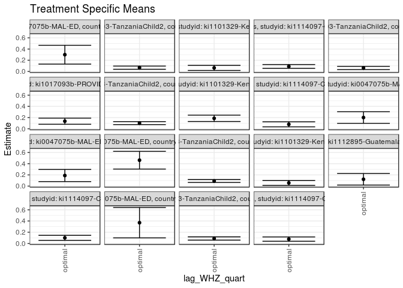

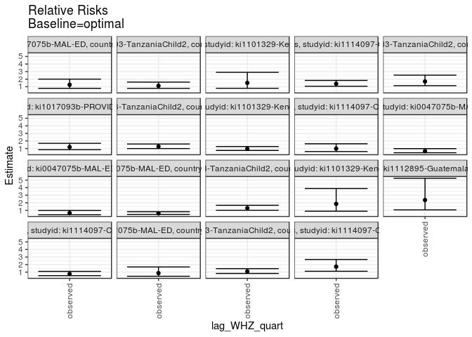

## Results Table

### Parameter: TSM

| agecat | studyid | country | intervention_level | baseline_level | estimate | ci_lower | ci_upper |
| --- | --- | --- | --- | --- | --- | --- | --- |
| 3-6 months | ki1017093b-PROVIDE | BANGLADESH | optimal | NA | 0.1351711 | 0.0806939 | 0.1896484 |
| 3-6 months | ki1066203-TanzaniaChild2 | TANZANIA, UNITED REPUBLIC OF | optimal | NA | 0.1008527 | 0.0739318 | 0.1277736 |
| 3-6 months | ki1101329-Keneba | GAMBIA | optimal | NA | 0.1863515 | 0.1294470 | 0.2432560 |
| 3-6 months | ki1114097-CMIN | PERU | optimal | NA | 0.0790922 | 0.0338481 | 0.1243364 |
| 6-9 months | ki0047075b-MAL-ED | PERU | optimal | NA | 0.2005230 | 0.0970825 | 0.3039635 |
| 6-9 months | ki0047075b-MAL-ED | SOUTH AFRICA | optimal | NA | 0.1885735 | 0.0798244 | 0.2973226 |
| 6-9 months | ki0047075b-MAL-ED | TANZANIA, UNITED REPUBLIC OF | optimal | NA | 0.4621780 | 0.3042341 | 0.6201219 |
| 6-9 months | ki1066203-TanzaniaChild2 | TANZANIA, UNITED REPUBLIC OF | optimal | NA | 0.0907515 | 0.0647863 | 0.1167167 |
| 6-9 months | ki1101329-Keneba | GAMBIA | optimal | NA | 0.0567099 | 0.0124575 | 0.1009623 |
| 6-9 months | ki1112895-Guatemala BSC | GUATEMALA | optimal | NA | 0.1215829 | 0.0184297 | 0.2247361 |
| 6-9 months | ki1114097-CMIN | PERU | optimal | NA | 0.0995792 | 0.0546356 | 0.1445229 |
| 9-12 months | ki0047075b-MAL-ED | TANZANIA, UNITED REPUBLIC OF | optimal | NA | 0.3698448 | 0.0988261 | 0.6408635 |
| 9-12 months | ki1066203-TanzaniaChild2 | TANZANIA, UNITED REPUBLIC OF | optimal | NA | 0.0881401 | 0.0587620 | 0.1175182 |
| 9-12 months | ki1114097-CMIN | PERU | optimal | NA | 0.0771492 | 0.0388984 | 0.1154001 |
| 12-15 months | ki0047075b-MAL-ED | TANZANIA, UNITED REPUBLIC OF | optimal | NA | 0.2990845 | 0.1315828 | 0.4665862 |
| 12-15 months | ki1066203-TanzaniaChild2 | TANZANIA, UNITED REPUBLIC OF | optimal | NA | 0.0673313 | 0.0387203 | 0.0959424 |
| 12-15 months | ki1101329-Keneba | GAMBIA | optimal | NA | 0.0634496 | 0.0175103 | 0.1093889 |
| 12-15 months | ki1114097-CMIN | PERU | optimal | NA | 0.0893117 | 0.0556886 | 0.1229349 |
| 15-18 months | ki1066203-TanzaniaChild2 | TANZANIA, UNITED REPUBLIC OF | optimal | NA | 0.0623722 | 0.0338317 | 0.0909126 |

### Parameter: E(Y)

| agecat | studyid | country | intervention_level | baseline_level | estimate | ci_lower | ci_upper |
| --- | --- | --- | --- | --- | --- | --- | --- |
| 3-6 months | ki1017093b-PROVIDE | BANGLADESH | observed | NA | 0.1613508 | 0.1300924 | 0.1926093 |
| 3-6 months | ki1066203-TanzaniaChild2 | TANZANIA, UNITED REPUBLIC OF | observed | NA | 0.1268012 | 0.1125046 | 0.1410977 |
| 3-6 months | ki1101329-Keneba | GAMBIA | observed | NA | 0.1808511 | 0.1514199 | 0.2102822 |
| 3-6 months | ki1114097-CMIN | PERU | observed | NA | 0.0781250 | 0.0561896 | 0.1000604 |
| 6-9 months | ki0047075b-MAL-ED | PERU | observed | NA | 0.1317365 | 0.0802880 | 0.1831851 |
| 6-9 months | ki0047075b-MAL-ED | SOUTH AFRICA | observed | NA | 0.1213873 | 0.0725817 | 0.1701928 |
| 6-9 months | ki0047075b-MAL-ED | TANZANIA, UNITED REPUBLIC OF | observed | NA | 0.2795031 | 0.2099691 | 0.3490371 |
| 6-9 months | ki1066203-TanzaniaChild2 | TANZANIA, UNITED REPUBLIC OF | observed | NA | 0.1174017 | 0.1019953 | 0.1328080 |
| 6-9 months | ki1101329-Keneba | GAMBIA | observed | NA | 0.1051724 | 0.0801845 | 0.1301603 |
| 6-9 months | ki1112895-Guatemala BSC | GUATEMALA | observed | NA | 0.2865169 | 0.2199085 | 0.3531252 |
| 6-9 months | ki1114097-CMIN | PERU | observed | NA | 0.0761062 | 0.0542221 | 0.0979903 |
| 9-12 months | ki0047075b-MAL-ED | TANZANIA, UNITED REPUBLIC OF | observed | NA | 0.3230769 | 0.2423765 | 0.4037774 |
| 9-12 months | ki1066203-TanzaniaChild2 | TANZANIA, UNITED REPUBLIC OF | observed | NA | 0.0964230 | 0.0802843 | 0.1125618 |
| 9-12 months | ki1114097-CMIN | PERU | observed | NA | 0.1332046 | 0.1039145 | 0.1624947 |
| 12-15 months | ki0047075b-MAL-ED | TANZANIA, UNITED REPUBLIC OF | observed | NA | 0.3736264 | 0.2736811 | 0.4735717 |
| 12-15 months | ki1066203-TanzaniaChild2 | TANZANIA, UNITED REPUBLIC OF | observed | NA | 0.0752119 | 0.0583791 | 0.0920447 |
| 12-15 months | ki1101329-Keneba | GAMBIA | observed | NA | 0.0959596 | 0.0669135 | 0.1250057 |
| 12-15 months | ki1114097-CMIN | PERU | observed | NA | 0.1241685 | 0.0936995 | 0.1546375 |
| 15-18 months | ki1066203-TanzaniaChild2 | TANZANIA, UNITED REPUBLIC OF | observed | NA | 0.1056241 | 0.0832975 | 0.1279508 |

### Parameter: RR

| agecat | studyid | country | intervention_level | baseline_level | estimate | ci_lower | ci_upper |
| --- | --- | --- | --- | --- | --- | --- | --- |
| 3-6 months | ki1017093b-PROVIDE | BANGLADESH | observed | optimal | 1.1936782 | 0.8421681 | 1.6919040 |
| 3-6 months | ki1066203-TanzaniaChild2 | TANZANIA, UNITED REPUBLIC OF | observed | optimal | 1.2572903 | 0.9884051 | 1.5993228 |
| 3-6 months | ki1101329-Keneba | GAMBIA | observed | optimal | 0.9704836 | 0.7464471 | 1.2617617 |
| 3-6 months | ki1114097-CMIN | PERU | observed | optimal | 0.9877710 | 0.6002373 | 1.6255098 |
| 6-9 months | ki0047075b-MAL-ED | PERU | observed | optimal | 0.6569646 | 0.4396438 | 0.9817096 |
| 6-9 months | ki0047075b-MAL-ED | SOUTH AFRICA | observed | optimal | 0.6437134 | 0.4174668 | 0.9925746 |
| 6-9 months | ki0047075b-MAL-ED | TANZANIA, UNITED REPUBLIC OF | observed | optimal | 0.6047521 | 0.4481462 | 0.8160843 |
| 6-9 months | ki1066203-TanzaniaChild2 | TANZANIA, UNITED REPUBLIC OF | observed | optimal | 1.2936607 | 1.0046504 | 1.6658113 |
| 6-9 months | ki1101329-Keneba | GAMBIA | observed | optimal | 1.8545675 | 0.8857735 | 3.8829572 |
| 6-9 months | ki1112895-Guatemala BSC | GUATEMALA | observed | optimal | 2.3565557 | 1.0606661 | 5.2357239 |
| 6-9 months | ki1114097-CMIN | PERU | observed | optimal | 0.7642778 | 0.5308701 | 1.1003081 |
| 9-12 months | ki0047075b-MAL-ED | TANZANIA, UNITED REPUBLIC OF | observed | optimal | 0.8735472 | 0.4532566 | 1.6835601 |
| 9-12 months | ki1066203-TanzaniaChild2 | TANZANIA, UNITED REPUBLIC OF | observed | optimal | 1.0939743 | 0.8205869 | 1.4584435 |
| 9-12 months | ki1114097-CMIN | PERU | observed | optimal | 1.7265838 | 1.1149648 | 2.6737090 |
| 12-15 months | ki0047075b-MAL-ED | TANZANIA, UNITED REPUBLIC OF | observed | optimal | 1.2492335 | 0.7791943 | 2.0028179 |
| 12-15 months | ki1066203-TanzaniaChild2 | TANZANIA, UNITED REPUBLIC OF | observed | optimal | 1.1170414 | 0.7773836 | 1.6051039 |
| 12-15 months | ki1101329-Keneba | GAMBIA | observed | optimal | 1.5123756 | 0.7881217 | 2.9021914 |
| 12-15 months | ki1114097-CMIN | PERU | observed | optimal | 1.3902820 | 1.0549635 | 1.8321808 |
| 15-18 months | ki1066203-TanzaniaChild2 | TANZANIA, UNITED REPUBLIC OF | observed | optimal | 1.6934501 | 1.1334670 | 2.5300898 |

### Parameter: PAR

| agecat | studyid | country | intervention_level | baseline_level | estimate | ci_lower | ci_upper |
| --- | --- | --- | --- | --- | --- | --- | --- |
| 3-6 months | ki1017093b-PROVIDE | BANGLADESH | optimal | NA | 0.0261797 | -0.0211215 | 0.0734809 |
| 3-6 months | ki1066203-TanzaniaChild2 | TANZANIA, UNITED REPUBLIC OF | optimal | NA | 0.0259484 | 0.0015398 | 0.0503571 |
| 3-6 months | ki1101329-Keneba | GAMBIA | optimal | NA | -0.0055004 | -0.0543979 | 0.0433971 |
| 3-6 months | ki1114097-CMIN | PERU | optimal | NA | -0.0009672 | -0.0403663 | 0.0384319 |
| 6-9 months | ki0047075b-MAL-ED | PERU | optimal | NA | -0.0687865 | -0.1497198 | 0.0121468 |
| 6-9 months | ki0047075b-MAL-ED | SOUTH AFRICA | optimal | NA | -0.0671862 | -0.1519674 | 0.0175950 |
| 6-9 months | ki0047075b-MAL-ED | TANZANIA, UNITED REPUBLIC OF | optimal | NA | -0.1826749 | -0.3179630 | -0.0473868 |
| 6-9 months | ki1066203-TanzaniaChild2 | TANZANIA, UNITED REPUBLIC OF | optimal | NA | 0.0266502 | 0.0034771 | 0.0498232 |
| 6-9 months | ki1101329-Keneba | GAMBIA | optimal | NA | 0.0484625 | 0.0052074 | 0.0917175 |
| 6-9 months | ki1112895-Guatemala BSC | GUATEMALA | optimal | NA | 0.1649340 | 0.0633478 | 0.2665201 |
| 6-9 months | ki1114097-CMIN | PERU | optimal | NA | -0.0234730 | -0.0600087 | 0.0130626 |
| 9-12 months | ki0047075b-MAL-ED | TANZANIA, UNITED REPUBLIC OF | optimal | NA | -0.0467679 | -0.2912710 | 0.1977352 |
| 9-12 months | ki1066203-TanzaniaChild2 | TANZANIA, UNITED REPUBLIC OF | optimal | NA | 0.0082829 | -0.0170942 | 0.0336600 |
| 9-12 months | ki1114097-CMIN | PERU | optimal | NA | 0.0560554 | 0.0205117 | 0.0915991 |
| 12-15 months | ki0047075b-MAL-ED | TANZANIA, UNITED REPUBLIC OF | optimal | NA | 0.0745419 | -0.0665185 | 0.2156023 |
| 12-15 months | ki1066203-TanzaniaChild2 | TANZANIA, UNITED REPUBLIC OF | optimal | NA | 0.0078805 | -0.0166011 | 0.0323622 |
| 12-15 months | ki1101329-Keneba | GAMBIA | optimal | NA | 0.0325100 | -0.0098111 | 0.0748311 |
| 12-15 months | ki1114097-CMIN | PERU | optimal | NA | 0.0348568 | 0.0090854 | 0.0606281 |
| 15-18 months | ki1066203-TanzaniaChild2 | TANZANIA, UNITED REPUBLIC OF | optimal | NA | 0.0432520 | 0.0167718 | 0.0697322 |

### Parameter: PAF

| agecat | studyid | country | intervention_level | baseline_level | estimate | ci_lower | ci_upper |
| --- | --- | --- | --- | --- | --- | --- | --- |
| 3-6 months | ki1017093b-PROVIDE | BANGLADESH | optimal | NA | 0.1622533 | -0.1874114 | 0.4089499 |
| 3-6 months | ki1066203-TanzaniaChild2 | TANZANIA, UNITED REPUBLIC OF | optimal | NA | 0.2046387 | -0.0117309 | 0.3747354 |
| 3-6 months | ki1101329-Keneba | GAMBIA | optimal | NA | -0.0304141 | -0.3396796 | 0.2074573 |
| 3-6 months | ki1114097-CMIN | PERU | optimal | NA | -0.0123804 | -0.6660079 | 0.3848084 |
| 6-9 months | ki0047075b-MAL-ED | PERU | optimal | NA | -0.5221519 | -1.2745686 | -0.0186312 |
| 6-9 months | ki0047075b-MAL-ED | SOUTH AFRICA | optimal | NA | -0.5534864 | -1.3954001 | -0.0074809 |
| 6-9 months | ki0047075b-MAL-ED | TANZANIA, UNITED REPUBLIC OF | optimal | NA | -0.6535702 | -1.2314148 | -0.2253637 |
| 6-9 months | ki1066203-TanzaniaChild2 | TANZANIA, UNITED REPUBLIC OF | optimal | NA | 0.2269998 | 0.0046289 | 0.3996919 |
| 6-9 months | ki1101329-Keneba | GAMBIA | optimal | NA | 0.4607907 | -0.1289568 | 0.7424643 |
| 6-9 months | ki1112895-Guatemala BSC | GUATEMALA | optimal | NA | 0.5756519 | 0.0571962 | 0.8090044 |
| 6-9 months | ki1114097-CMIN | PERU | optimal | NA | -0.3084247 | -0.8837001 | 0.0911636 |
| 9-12 months | ki0047075b-MAL-ED | TANZANIA, UNITED REPUBLIC OF | optimal | NA | -0.1447578 | -1.2062556 | 0.4060206 |
| 9-12 months | ki1066203-TanzaniaChild2 | TANZANIA, UNITED REPUBLIC OF | optimal | NA | 0.0859017 | -0.2186399 | 0.3143375 |
| 9-12 months | ki1114097-CMIN | PERU | optimal | NA | 0.4208216 | 0.1031107 | 0.6259877 |
| 12-15 months | ki0047075b-MAL-ED | TANZANIA, UNITED REPUBLIC OF | optimal | NA | 0.1995091 | -0.2833770 | 0.5007035 |
| 12-15 months | ki1066203-TanzaniaChild2 | TANZANIA, UNITED REPUBLIC OF | optimal | NA | 0.1047780 | -0.2863663 | 0.3769874 |
| 12-15 months | ki1101329-Keneba | GAMBIA | optimal | NA | 0.3387886 | -0.2688395 | 0.6554328 |
| 12-15 months | ki1114097-CMIN | PERU | optimal | NA | 0.2807214 | 0.0520999 | 0.4542023 |
| 15-18 months | ki1066203-TanzaniaChild2 | TANZANIA, UNITED REPUBLIC OF | optimal | NA | 0.4094895 | 0.1177511 | 0.6047571 |